# Linear Regression

## Linear Regression

A linear regression is a linear approximation of a causal relationship between two or more variables.

- $Y$ = Dependent variable = predicted
- $x_1$, $x_2$, $x_3$, $x_k$ = Independent variable = predictors

The dependent variable Y is a function of the independent variables x1 to k:

- $Y$ = F($x_1, x_2, x_3,…,x_k$)

Simple Linear Regression:

- $y = β_0 + β_1x_1 + ε $
- $β_1$ = quantifies the effect of $x_1$ on $Y$
- $β_0$ = constant (for example minimum salary)
- ε = error of estimation (residual)

**NOTE**: Correlation is does not imply causation!

- Correlation measures the degree of relationship between 2 variables, also movement together: p(x,y) = p(y,x), graphical presentation is different: single point.
- Regression measures how one variable affects another, also it only 1 way, a line as a graph.

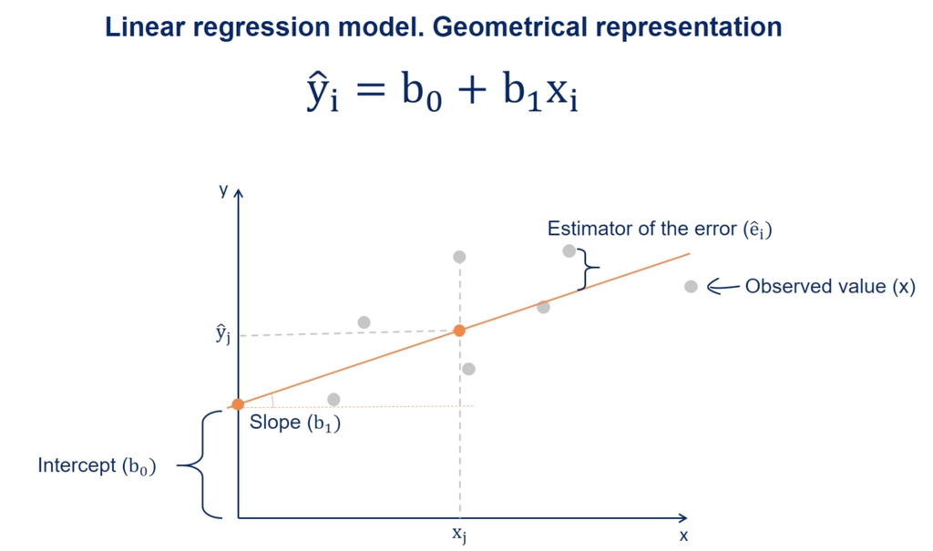

```python
from IPython.display import Image
PATH = "/Users/peterhng/Desktop/"
Image(filename = PATH + "Képernyőfotó 2019-04-12 - 18.06.33.png",width=500, height=500)
```

### The whole code

```python
import pandas as pd
import numpy as np
import matplotlib.pyplot as plt
import seaborn as sns
import statsmodels.api as sm

%matplotlib inline
```

```python
DF = pd.read_csv("/Users/peterhng/Dropbox/1.01. Simple linear regression.csv")
```

```python
DF.head()
```

|  | SAT | GPA |
| --- | --- | --- |
| 0 | 1714 | 2.40 |
| 1 | 1664 | 2.52 |
| 2 | 1760 | 2.54 |
| 3 | 1685 | 2.74 |
| 4 | 1693 | 2.83 |

```python
y = DF["GPA"]
x1 = DF["SAT"]
```

#### Explore the data

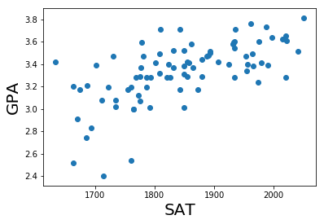

```python
plt.scatter(x1,y)
plt.xlabel("SAT", fontsize=20)
plt.ylabel("GPA", fontsize=20)
```

```python
x = sm.add_constant(x1)
results = sm.OLS(y,x).fit
results.summary()
```

[output not shown]

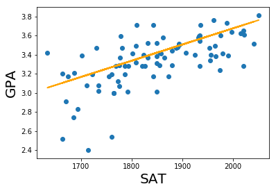

```python
plt.scatter(x1,y)
yhat = 0.0017*x1+0.275
fig = plt.plot(x1, yhat, lw=2, c="orange")
plt.xlabel("SAT", fontsize=20)
plt.ylabel("GPA", fontsize=20)
```

### ANOVA table

- Sum of Squares Total
- Sum of Squares Regression
- Sum of Square Error

SST = Sum of Squares Total = Observed variables minus the its mean. Measure the total variability of the dataset:

$\sum\limits_{i=1}^{n} = (y_i-y)^2$

SSR = Sum of Squares Regression = Total differences of the predicted value and the mean dependent value, measures the explained variablity by your line

SSE = Sum of Square Error = Measures the unexplained variability by the regression.

$\sum\limits_{i=1}^{n} = ε_i^2$

SST = SSR + SSE

OLS = Ordinary Least Square --> min SSE

$R_2$ = $SSR/SST$

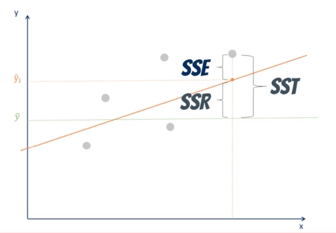

```python
PATH = "/Users/peterhng/Desktop/"
Image(filename = PATH + "Képernyőfotó 2019-04-12 - 21.02.14.png",width=500, height=500)
```

#### Advanced Method

```python
y = DF["GPA"]
X = DF["SAT"]
from sklearn.model_selection import train_test_split
```

```python
X_train, X_test, y_train, y_test = train_test_split(X, y, test_size=0.3, random_state=101)
```

```python
from sklearn.linear_model import LinearRegression
linmodel = LinearRegression()
linmodel.fit(X_train,y_train)
```

[output not shown]

```python
predictions = linmodel.predict(X_test)
```

[output not shown]

```python
from sklearn.metrics import classification_report, confusion_matrix
```

```python
confusion_matrix(y_test, predictions)
classification_report(y_test,predictions)
```